# Project: Investigate a Dataset - [Missed_Apts]

- Introduction
- Data Wrangling
- Exploratory Data Analysis
- Conclusions

## Introduction

### Dataset Description

The dataset titled "Missed Appointments" contains information about medical appointments in a Brazilian healthcare system, focusing on whether patients showed up for their appointments or not. This dataset includes the following columns:

```
PatientId: Unique identifier for each patient.
AppointmentID: Unique identifier for each appointment.
Gender: Gender of the patient (M for male, F for female).
ScheduledDay: Date and time when the appointment was scheduled.
AppointmentDay: Date of the appointment.
Age: Age of the patient.
Neighbourhood: Location of the hospital.
Scholarship: Whether the patient is enrolled in the Bolsa Família welfare program (1 for true, 0 for false).
Hipertension: Whether the patient has hypertension (1 for true, 0 for false).
Diabetes: Whether the patient has diabetes (1 for true, 0 for false).
Alcoholism: Whether the patient is an alcoholic (1 for true, 0 for false).
Handcap: Number of disabilities the patient has (0 to 4).
SMS_received: Whether the patient received an SMS reminder about the appointment (1 for true, 0 for false).
No-show: Whether the patient showed up for the appointment (Yes if they did not show up, No if they showed up).
```

### Question(s) for Analysis

What is the overall appointment show-up vs. no show-up rate?

Hypothesis: Patients with certain demographic or health characteristics may have different rates of appointment attendance.

Do missed appointments correlate with the need for follow-up appointments?

```
Hypothesis: Patients who miss their initial appointments are more likely to require follow-up appointments compared to those who attend their scheduled appointments.
```

```python
# Use this cell to set up import statements for all of the packages that you
#   plan to use.

# While optional for current notebooks, if you are having trouble with visualizations,
#   remember to include a 'magic word' so that your visualizations are plotted
#   inline with the notebook. See this page for more:
#   http://ipython.readthedocs.io/en/stable/interactive/magics.html

import pandas as pd
import matplotlib.pyplot as plt
import seaborn as sns

# This line ensures that plots are displayed inline in the notebook
%matplotlib inline
```

```python
#In this step, we load the dataset Missed_apts.csv
using Pandas and display the first few rows to get an initial look at the data.

df = pd.read_csv('Missed_apts.csv')
# Display first few rows to understand the structure
print("First few rows:")
print(df.head(), "\n")
```

```
First few rows:
      PatientId  AppointmentID Gender          ScheduledDay  \
0  2.987250e+13        5642903      F  2016-04-29T18:38:08Z
1  5.589978e+14        5642503      M  2016-04-29T16:08:27Z
2  4.262962e+12        5642549      F  2016-04-29T16:19:04Z
3  8.679512e+11        5642828      F  2016-04-29T17:29:31Z
4  8.841186e+12        5642494      F  2016-04-29T16:07:23Z

         AppointmentDay  Age      Neighbourhood  Scholarship  Hipertension  \
0  2016-04-29T00:00:00Z   62    JARDIM DA PENHA            0             1
1  2016-04-29T00:00:00Z   56    JARDIM DA PENHA            0             0
2  2016-04-29T00:00:00Z   62      MATA DA PRAIA            0             0
3  2016-04-29T00:00:00Z    8  PONTAL DE CAMBURI            0             0
4  2016-04-29T00:00:00Z   56    JARDIM DA PENHA            0             1

   Diabetes  Alcoholism  Handcap  SMS_received No-show
0         0           0        0             0      No
1         0           0        0             0      No
2         0           0        0             0      No
3         0           0        0             0      No
4         1           0        0             0      No
```

```python
#Here, we retrieve the size of the dataframe,
which tells us the number of rows and columns present in the dataset.

# Get the size of the dataframe
print(f"Dataframe size: {df.shape}")
```

```
Dataframe size: (110527, 14)
```

```python
#Using df.info(), we obtain a summary of the dataframe including column names,
non-null counts, and data types.
This helps us understand what types of data are present in each column.


df.info()
```

```
<class 'pandas.core.frame.DataFrame'>
RangeIndex: 110527 entries, 0 to 110526
Data columns (total 14 columns):
 #   Column          Non-Null Count   Dtype
---  ------          --------------   -----
 0   PatientId       110527 non-null  float64
 1   AppointmentID   110527 non-null  int64
 2   Gender          110527 non-null  object
 3   ScheduledDay    110527 non-null  object
 4   AppointmentDay  110527 non-null  object
 5   Age             110527 non-null  int64
 6   Neighbourhood   110527 non-null  object
 7   Scholarship     110527 non-null  int64
 8   Hipertension    110527 non-null  int64
 9   Diabetes        110527 non-null  int64
 10  Alcoholism      110527 non-null  int64
 11  Handcap         110527 non-null  int64
 12  SMS_received    110527 non-null  int64
 13  No-show         110527 non-null  object
dtypes: float64(1), int64(8), object(5)
memory usage: 11.8+ MB
```

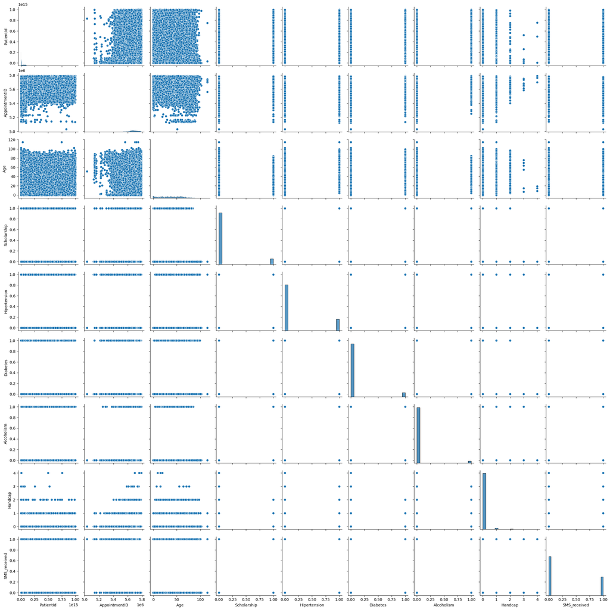

```python
#The pair plot below provides a visual overview of the relationships between numeric variables in the dataset.
Each scatterplot in the grid represents the relationship between two variables,
with histograms along the diagonal showing the distribution of each variable.

sns.pairplot(df);
```

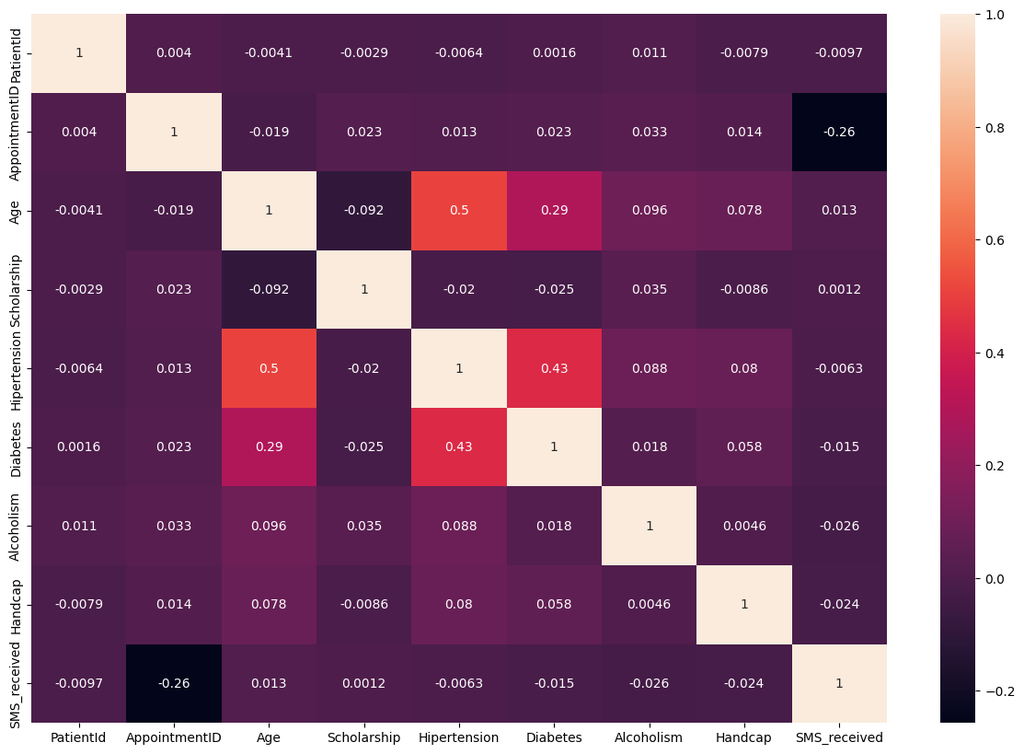

```python
#The correlation heatmap below visualizes the pairwise correlations between numeric variables in the dataset.
This plot helps to identify relationships and dependencies among variables.

import numpy as np
# Select only numeric columns for correlation calculation
numeric_columns = df.select_dtypes(include=np.number)

# Calculate correlation
corr_matrix = numeric_columns.corr()

# Plot the heatmap
fig, ax = plt.subplots(figsize=(15, 10))
sns.heatmap(corr_matrix, annot=True, ax=ax)
plt.show()
```

## Data Wrangling

### General Properties

```python
#To ensure data completeness, we check for missing values across all columns:

# Check for missing values
print(df.isnull().sum())


# Display data types
print(df.dtypes)
```

```
PatientId         0
AppointmentID     0
Gender            0
ScheduledDay      0
AppointmentDay    0
Age               0
Neighbourhood     0
Scholarship       0
Hipertension      0
Diabetes          0
Alcoholism        0
Handcap           0
SMS_received      0
No-show           0
dtype: int64
PatientId         float64
AppointmentID       int64
Gender             object
ScheduledDay       object
AppointmentDay     object
Age                 int64
Neighbourhood      object
Scholarship         int64
Hipertension        int64
Diabetes            int64
Alcoholism          int64
Handcap             int64
SMS_received        int64
No-show            object
dtype: object
```

```python
#to ensure data uniqueness, we check for duplicated rows in the entire dataset:

df.duplicated().sum()
```

```
0
```

```python
#Check for duplicated values in the AppointmentID column:

sum(df.AppointmentID.duplicated())
```

```
0
```

```python
#Similarly, check for duplicated values in the PatientId column:

sum(df.PatientId.duplicated())
```

```
48228
```

```python
#To improve data quality, columns with a high percentage of missing values are dropped if they exist:

#If applicable, missing values in the 'runtime' column are filled with the median:

#Convert release_date column to datetime format if it's not already:

#Columns that are not necessary for further analysis are removed from the DataFrame:


# Drop columns with a high percentage of missing values if they exist
columns_to_drop = ['homepage', 'tagline']
for column in columns_to_drop:
    if column in df.columns:
        df = df.drop(columns=[column])

# Display the columns to verify the changes
print(df.columns)

# Check if 'runtime' column exists before attempting to fill missing values
if 'runtime' in df.columns:
    # Fill missing values in the 'runtime' column with the median
    df['runtime'] = df['runtime'].fillna(df['runtime'].median())

# Convert 'release_date' to datetime format if it's not already
if 'release_date' in df.columns and df['release_date'].dtype == 'object':
    df['release_date'] = pd.to_datetime(df['release_date'])

# Drop columns that are not necessary for analysis
columns_to_remove = ['id', 'imdb_id', 'overview', 'keywords']
for column in columns_to_remove:
    if column in df.columns:
        df = df.drop(columns=[column])

# Display the cleaned DataFrame info to ensure everything is in order
print(df.info())
```

```
Index(['PatientId', 'AppointmentID', 'Gender', 'ScheduledDay',
       'AppointmentDay', 'Age', 'Neighbourhood', 'Scholarship', 'Hipertension',
       'Diabetes', 'Alcoholism', 'Handcap', 'SMS_received', 'No-show'],
      dtype='object')
<class 'pandas.core.frame.DataFrame'>
RangeIndex: 110527 entries, 0 to 110526
Data columns (total 14 columns):
 #   Column          Non-Null Count   Dtype
---  ------          --------------   -----
 0   PatientId       110527 non-null  float64
 1   AppointmentID   110527 non-null  int64
 2   Gender          110527 non-null  object
 3   ScheduledDay    110527 non-null  object
 4   AppointmentDay  110527 non-null  object
 5   Age             110527 non-null  int64
 6   Neighbourhood   110527 non-null  object
 7   Scholarship     110527 non-null  int64
 8   Hipertension    110527 non-null  int64
 9   Diabetes        110527 non-null  int64
 10  Alcoholism      110527 non-null  int64
 11  Handcap         110527 non-null  int64
 12  SMS_received    110527 non-null  int64
 13  No-show         110527 non-null  object
dtypes: float64(1), int64(8), object(5)
memory usage: 11.8+ MB
None
```

```python
#This code snippet prints the summary statistics
(count, mean, standard deviation, min, 25th percentile, median, 75th percentile, and max)
of the DataFrame df, providing insights into the distribution and range of numerical data.

# Summary statistics of the dataframe
print(df.describe())
```

```
          PatientId  AppointmentID            Age    Scholarship  \
count  1.105270e+05   1.105270e+05  110527.000000  110527.000000
mean   1.474963e+14   5.675305e+06      37.088874       0.098266
std    2.560949e+14   7.129575e+04      23.110205       0.297675
min    3.921784e+04   5.030230e+06      -1.000000       0.000000
25%    4.172614e+12   5.640286e+06      18.000000       0.000000
50%    3.173184e+13   5.680573e+06      37.000000       0.000000
75%    9.439172e+13   5.725524e+06      55.000000       0.000000
max    9.999816e+14   5.790484e+06     115.000000       1.000000

        Hipertension       Diabetes     Alcoholism        Handcap  \
count  110527.000000  110527.000000  110527.000000  110527.000000
mean        0.197246       0.071865       0.030400       0.022248
std         0.397921       0.258265       0.171686       0.161543
min         0.000000       0.000000       0.000000       0.000000
25%         0.000000       0.000000       0.000000       0.000000
50%         0.000000       0.000000       0.000000       0.000000
75%         0.000000       0.000000       0.000000       0.000000
max         1.000000       1.000000       1.000000       4.000000

        SMS_received
count  110527.000000
mean        0.321026
std         0.466873
min         0.000000
25%         0.000000
50%         0.000000
75%         1.000000
max         1.000000
```

```python
#This code snippet prints the number of unique values in each column of the DataFrame df,
which helps in understanding the diversity and cardinality of data within each feature.

# Check for unique values in each column
print(df.nunique())
```

```
PatientId          62299
AppointmentID     110527
Gender                 2
ScheduledDay      103549
AppointmentDay        27
Age                  104
Neighbourhood         81
Scholarship            2
Hipertension           2
Diabetes               2
Alcoholism             2
Handcap                5
SMS_received           2
No-show                2
dtype: int64
```

```python
#This code snippet randomly selects and prints 5 rows from the DataFrame df,
providing a glimpse into the variation and distribution of data entries.

# Print a random sample of rows
print(df.sample(5))
```

```
          PatientId  AppointmentID Gender          ScheduledDay  \
73322  4.283945e+14        5701433      M  2016-05-16T10:31:58Z
88014  5.816289e+11        5760331      F  2016-06-01T14:40:47Z
20191  2.349963e+13        5730170      F  2016-05-24T08:15:17Z
56058  7.818528e+13        5654915      F  2016-05-03T15:28:49Z
56917  3.311239e+12        5587307      F  2016-04-15T08:31:57Z

             AppointmentDay  Age   Neighbourhood  Scholarship  Hipertension  \
73322  2016-05-16T00:00:00Z    1  GRANDE VITÓRIA            0             0
88014  2016-06-01T00:00:00Z    9        DA PENHA            0             0
20191  2016-05-24T00:00:00Z   52        SÃO JOSÉ            0             1
56058  2016-05-05T00:00:00Z   35        SÃO JOSÉ            0             0
56917  2016-05-19T00:00:00Z   56       CARATOÍRA            0             0

       Diabetes  Alcoholism  Handcap  SMS_received No-show
73322         0           0        0             0      No
88014         0           0        0             0      No
20191         0           0        0             0      No
56058         0           0        0             0     Yes
56917         0           0        0             0      No
```

### Data Cleaning

```python
# Use this, and more code cells, to explore your data. Don't forget to add
#   Markdown cells to document your observations and findings.


# Create a funtion to generate a bar plot the frequency table
# generated by the Show_NoShow_by_Group function.

def Show_No_Show_bar_plot(df, bygroup):
    df_by_Group = pd.crosstab(df[bygroup], df.Status, normalize = 'index')
    df_by_Group = np.round((df_by_Group * 100), decimals=2)
    ax = df_by_Group.plot.bar(figsize=(10,5));
    vals = ax.get_yticks()
    ax.set_yticklabels(['{:3.0f}%'.format(x) for x in vals]);
    ax.set_xticklabels(df_by_Group.index,rotation = 0, fontsize = 15);
    ax.set_title('\nShowUp vs. No ShowUp (%) (by ' + df_by_Group.index.name + ')\n', fontsize = 15)
    ax.set_xlabel(df_by_Group.index.name, fontsize = 12)
    ax.set_ylabel('(%)', fontsize = 12)
    ax.legend(loc = 'upper left',bbox_to_anchor=(1.0,1.0), fontsize= 12)
    rects = ax.patches

    # Add Data Labels

    for rect in rects:
        height = rect.get_height()
        ax.text(rect.get_x() + rect.get_width()/2,
                height + 2,
                str(height)+'%',
                ha='center',
                va='bottom',
                fontsize = 12)
    return df_by_Group
```

```python
# Create a funtion to calculate the plot the group proportions based on one variable by number of appointments

def PropByVar(df, variable):
    df_pie = df[variable].value_counts()
    ax = df_pie.plot.pie(figsize=(10,10), autopct='%1.2f%%', fontsize = 12);
    ax.set_title(variable + ' (%) (Per appointment)\n', fontsize = 15);
    return np.round(df_pie/df.shape[0]*100,2)
```

```python
# Create a funtion to calculate the plot the group proportions based on one variable

def NumOfPatients(df, variable):
    PatID_Count = pd.pivot_table(df, index=variable, values='PatientID',aggfunc = lambda x: len(x.unique()))
    ax = PatID_Count.plot.pie(figsize=(10,10), autopct='%1.2f%%', subplots=True, fontsize = 12, legend = False);
    plt.title(variable + ' (%) (Per patient)\n', fontsize = 15);
    return np.round(PatID_Count/sum(PatID_Count['PatientID'])*100,2)
```

```python
# Create a function to plot the noshow-up % for two variables (i.e. gender and hypertention)

def NoShowBy2Vars(df,var1, var2):
    Freq_df = pd.crosstab(df[var1], columns = df[var2], normalize = 'index')
    Freq_df = np.round(Freq_df * 100,2)
    ax = Freq_df.plot.barh(stacked = True,figsize=(10,5));
    ax.set_title('\nNo ShowUp (%) (by ' + str(var1) + ' & '+ str(var2) + ')\n', fontsize = 15);
    ax.set_ylabel(Freq_df.index.name, fontsize = 12)
    ax.set_xlabel('(%)', fontsize = 12)
    vals = ax.get_xticks()
    ax.set_xticklabels(['{:3.0f}%'.format(x) for x in vals])
    ax.tick_params(axis='both', which='major', labelsize=12)
    ax.legend(loc = 'upper left',bbox_to_anchor=(1.0,1.0), fontsize= 12)
    return Freq_df
```

```python
def Recurring_Patient_prct(df,var1,var2):

    # Pivot table to calcuate the patientID count
    PatID_Count = pd.pivot_table(df, index=var1, columns=var2, values='PatientID',aggfunc = lambda x: len(x.unique()))

    # Pivot table to calcuate the AppointmentID count
    AptID_Count = pd.pivot_table(df, index=var1, columns=var2, values='AppointmentID',aggfunc='count')

    # divide the two tables above to calculate the percentage and return the resulting table.
    Div_chck = np.round((1 - PatID_Count/AptID_Count)*100,2)

    ax = Div_chck.plot.bar(figsize=(10,5));
    vals = ax.get_yticks()
    ax.set_yticklabels(['{:3.0f}%'.format(x) for x in vals]);
    ax.set_xticklabels(Div_chck.index,rotation = 0, fontsize = 15);
    ax.set_title('\nRecurring Patients (%)\n', fontsize = 15)
    ax.set_xlabel(Div_chck.index.name, fontsize = 12)
    ax.set_ylabel('(%)', fontsize = 12)
    ax.legend(loc = 'upper left',bbox_to_anchor=(1.0,1.0), fontsize= 12)
    rects = ax.patches

    # Add Data Labels

    for rect in rects:
        height = rect.get_height()
        ax.text(rect.get_x() + rect.get_width()/2,
                height + 2,
                str(height)+'%',
                ha='center',
                va='bottom',
                fontsize = 12)

    return Div_chck
```

```python
def PropByVar(df, variable):
    if variable not in df.columns:
        print(f"Error: '{variable}' column not found in the DataFrame.")
        return

    df_pie = df[variable].value_counts()
    ax = df_pie.plot.pie(figsize=(10, 10), autopct='%1.2f%%', fontsize=12)
    ax.set_title(f'{variable} (%) (Per appointment)\n', fontsize=15)
    plt.show()
```

```python
print(df.columns)
```

```
Index(['PatientId', 'AppointmentID', 'Gender', 'ScheduledDay',
       'AppointmentDay', 'Age', 'Neighbourhood', 'Scholarship', 'Hipertension',
       'Diabetes', 'Alcoholism', 'Handcap', 'SMS_received', 'No-show'],
      dtype='object')
```

## Exploratory Data Analysis

> **Tip**: Now that you've trimmed and cleaned your data, you're ready to move on to exploration. **Compute statistics** and **create visualizations** with the goal of addressing the research questions that you posed in the Introduction section. You should compute the relevant statistics throughout the analysis when an inference is made about the data. Note that at least two or more kinds of plots should be created as part of the exploration, and you must compare and show trends in the varied visualizations. Remember to utilize the visualizations that the pandas library already has available.

> **Tip**: Investigate the stated question(s) from multiple angles. It is recommended that you be systematic with your approach. Look at one variable at a time, and then follow it up by looking at relationships between variables. You should explore at least three variables in relation to the primary question. This can be an exploratory relationship between three variables of interest, or looking at how two independent variables relate to a single dependent variable of interest. Lastly, you should perform both single-variable (1d) and multiple-variable (2d) explorations.